# k-means聚类算法：算法描述与iris鸢尾花实例

2312473-李一珩

2026-05-16

# 1. k-means 算法的数学描述

k-means 是一种基于**划分**的聚类方法，旨在将数据集划分为 $k$ 个互不相交的簇，使得每个样本与其所属簇中心的距离平方和最小化。

## 1.1 符号定义

- 数据集：$\mathcal{X} = \{x_1, x_2, \dots, x_n\}$，其中每个 $x_i \in \mathbb{R}^d$。
- 簇的个数：$k$（给定）。
- 簇的划分：$\mathcal{C} = \{C_1, C_2, \dots, C_k\}$，满足 $C_i \neq \emptyset$，$\bigcup_{i=1}^k C_i = \mathcal{X}$，且 $C_i \cap C_j = \emptyset \ (i \neq j)$。
- 簇中心（质心）：$\mu_j = \frac{1}{|C_j|} \sum_{x \in C_j} x$，即簇内所有点的均值向量。

## 1.2 目标函数（损失函数）

k-means 最小化**簇内平方和**（Within-Cluster Sum of Squares, WCSS）：

$$\text{WCSS} = \sum_{j=1}^k \sum_{x \in C_j} \|x - \mu_j\|^2$$

其中 $\|\cdot\|$ 表示欧几里得距离。

## 1.3 迭代优化步骤

由于直接求解上述组合优化问题是 NP 难的，k-means 采用**启发式迭代**算法，通常称为 **Lloyd 算法**：

1. **初始化**：选择 $k$ 个样本点作为初始簇中心 $\mu_1^{(0)}, \mu_2^{(0)}, \dots, \mu_k^{(0)}$（常用随机选取或 k-means++）。
2. **分配（Assignment step）**：将每个样本点分配到最近的簇中心：
   $$C_j^{(t)} = \left\{ x_i : \|x_i - \mu_j^{(t)}\|^2 \le \|x_i -
   \mu_l^{(t)}\|^2 \ \forall l \in \{1,\dots,k\} \right\}$$
3. **更新（Update step）**：重新计算每个簇的质心：
   $$\mu_j^{(t+1)} = \frac{1}{|C_j^{(t)}|} \sum_{x \in C_j^{(t)}} x$$
4. **收敛判断**：重复步骤 2 和 3，直到簇中心不再变化（或变化小于阈值），或达到最大迭代次数。

## 1.4 算法性质

- **收敛性**：每次迭代 WCSS 严格下降（或保持不变），且存在下界，因此算法必然收敛（但不一定收敛到全局最优）。
- **时间复杂度**：$O(I \cdot k \cdot n \cdot d)$，其中 $I$ 为迭代次数，通常较小。
- **局限性**：
  - 需要预先指定 $k$。
  - 对初始中心敏感，易陷入局部最优。
  - 对噪声和异常值敏感（因为使用平方距离）。
  - 假设簇是凸的、大小相近、球形分布。

# 2. k-means 实例——基于R自带的iris鸢尾花数据集

使用 R 内置的 `iris` 鸢尾花数据集

去除物种标签，仅用四个数值特征，我们将展示：

- 如何确定最佳 $k$（肘部法则）；
- 执行 k-means 聚类；
- 可视化聚类结果（降维后展示）。

## 2.1 加载数据与预处理

```r
data(iris)
# 只使用数值特征
iris_features <- iris[, 1:4]
head(iris_features)
```

```
##   Sepal.Length Sepal.Width Petal.Length Petal.Width
## 1          5.1         3.5          1.4         0.2
## 2          4.9         3.0          1.4         0.2
## 3          4.7         3.2          1.3         0.2
## 4          4.6         3.1          1.5         0.2
## 5          5.0         3.6          1.4         0.2
## 6          5.4         3.9          1.7         0.4
```

## 2.2 确定簇的数量：肘部法则

计算不同 $k$（2~10）对应的 WCSS，选择“肘部”位置。

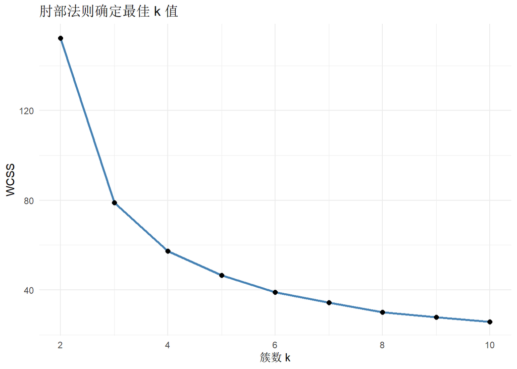

```r
set.seed(123)
wcss <- sapply(2:10, function(k) {
  kmeans(iris_features, centers = k, nstart = 25)$tot.withinss
})

elbow_df <- data.frame(k = 2:10, wcss = wcss)

ggplot(elbow_df, aes(x = k, y = wcss)) +
  geom_line(color = "steelblue", size = 1) +
  geom_point(size = 2) +
  labs(title = "肘部法则确定最佳 k 值", x = "簇数 k", y = "WCSS") +
  theme_minimal()
```

图中显示在 $k=3$ 处出现明显“肘点”，与 iris 真实类别数一致，因此选择 $k=3$。

## 2.3 执行 k-means 聚类

```r
set.seed(123)
km_result <- kmeans(iris_features, centers = 3, nstart = 25)
# 查看聚类结果摘要
table(km_result$cluster)
```

```
##
##  1  2  3
## 50 62 38
```

## 2.4 可视化聚类结果

由于原始数据是四维的，我们使用 PCA 降维到二维平面来展示聚类效果。

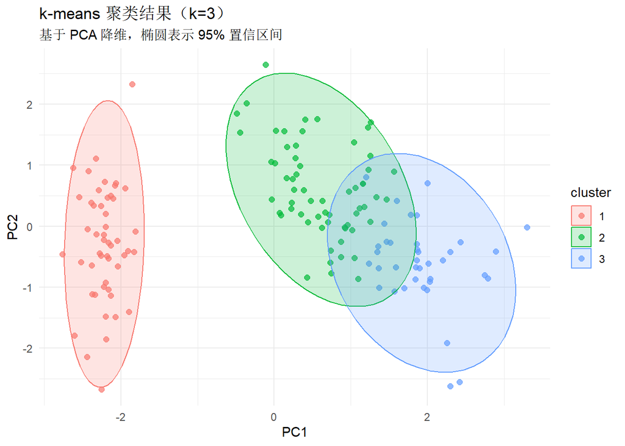

```r
# 执行 PCA
pca <- prcomp(iris_features, scale. = TRUE)
pca_df <- as.data.frame(pca$x[, 1:2])
pca_df$cluster <- as.factor(km_result$cluster)
pca_df$species <- iris$Species  # 真实标签（仅用于对照）

# 绘制聚类结果（颜色表示算法分配的簇）
ggplot(pca_df, aes(x = PC1, y = PC2, color = cluster)) +
  geom_point(size = 2, alpha = 0.7) +
  stat_ellipse(aes(fill = cluster), type = "norm", alpha = 0.2, geom = "polygon") +
  labs(title = "k-means 聚类结果（k=3）",
       subtitle = "基于 PCA 降维，椭圆表示 95% 置信区间") +
  theme_minimal()
```

为验证聚类效果，可以对照真实物种标签：

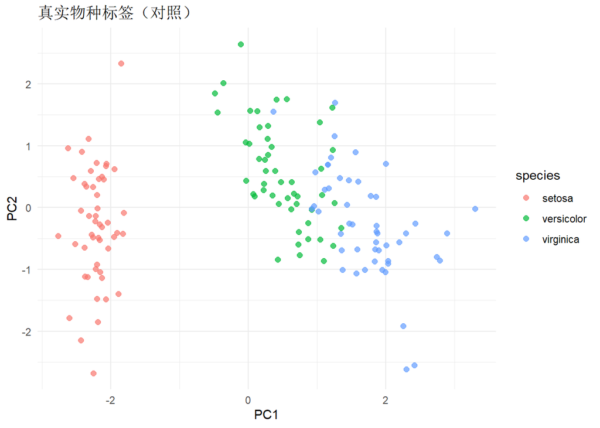

```r
ggplot(pca_df, aes(x = PC1, y = PC2, color = species)) +
  geom_point(size = 2, alpha = 0.7) +
  labs(title = "真实物种标签（对照）") +
  theme_minimal()
```

可以看到，k-means 聚类结果与真实类别高度吻合，仅有少量样本可能被混淆。

## 2.5 输出簇中心信息

```r
centers <- km_result$centers
colnames(centers) <- names(iris_features)
knitr::kable(centers, caption = "三个簇的中心（原始特征尺度）")
```

三个簇的中心（原始特征尺度）

| Sepal.Length | Sepal.Width | Petal.Length | Petal.Width |
| --- | --- | --- | --- |
| 5.006000 | 3.428000 | 1.462000 | 0.246000 |
| 5.901613 | 2.748387 | 4.393548 | 1.433871 |
| 6.850000 | 3.073684 | 5.742105 | 2.071053 |

# 3. 总结

- **数学描述**：k-means 通过最小化簇内平方和来划分数据，迭代执行“分配-更新”两步，是一种简单高效的聚类算法。
- **实例演示**：对鸢尾花数据集，肘部法则确定最佳簇数 $k=3$，聚类结果与真实类别高度一致，验证了算法的有效性。

[output not shown]